# Creating R Packages: A Tutorial

## 8.0 First Git Commit

Now that we’ve created the R function, it’s time to do our first commit so our work so far can be saved.

To do this, switch to the Git tab and press the Commit button:

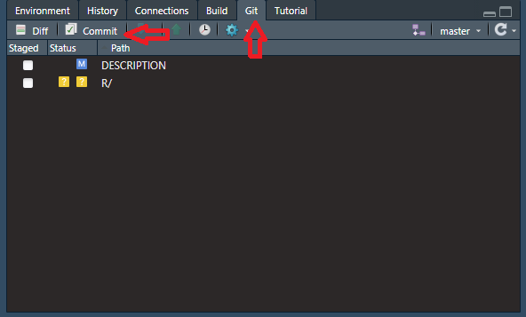

Git Commit

A new window will open showing you the changes you made from your last commit. Click the Stage button first to stage the changes, the the Commit button. You should also enter some helpful text to document the changes you are committing:

[figure not shown]

Git Commit

You will then see a confirmation window similar to the below:

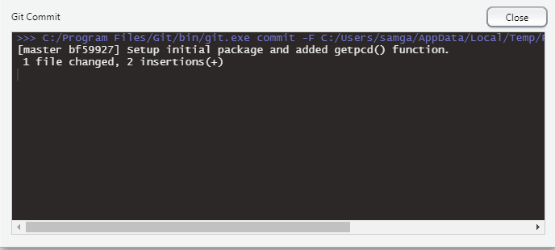

Git Commit

## 9.0 Checking the Whole Package

Now that we successfully tested the `getpcd()` function and saved our changes, it’s time to run some checks on the package as a whole (all the files, imports, documentation, etc.) to see if any issues exist. The command to do this is check():

```r
check()
```

The command runs an extensive series of checks and outputs its findings:

```r
Updating PCD documentation
Loading PCD
-- Building ------------------------------------------------------------------ PCD --
Setting env vars:
* CFLAGS    : -Wall -pedantic
* CXXFLAGS  : -Wall -pedantic
* CXX11FLAGS: -Wall -pedantic
-------------------------------------------------------------------------------------
WARNING: Rtools is required to build R packages, but is not currently installed.

Please download and install Rtools 4.0 from https://cran.r-project.org/bin/windows/Rtools/.
√  checking for file 'C:\Users\samga\PCD/DESCRIPTION' (481ms)
-  preparing 'PCD': (347ms)
√  checking DESCRIPTION meta-information ...
-  checking for LF line-endings in source and make files and shell scripts
-  checking for empty or unneeded directories
   Removed empty directory 'PCD/man'
-  building 'PCD_0.0.0.9000.tar.gz'

-- Checking ------------------------------------------------------------------ PCD --
Setting env vars:
* _R_CHECK_CRAN_INCOMING_REMOTE_: FALSE
* _R_CHECK_CRAN_INCOMING_       : FALSE
* _R_CHECK_FORCE_SUGGESTS_      : FALSE
* NOT_CRAN                      : true
-- R CMD check ----------------------------------------------------------------------
-  using log directory 'C:/Users/samga/AppData/Local/Temp/Rtmpmadly6/PCD.Rcheck' (514ms)
-  using R version 4.0.4 (2021-02-15)
-  using platform: x86_64-w64-mingw32 (64-bit)
-  using session charset: ISO8859-1
-  using options '--no-manual --as-cran'
√  checking for file 'PCD/DESCRIPTION' ...
-  this is package 'PCD' version '0.0.0.9000'
-  package encoding: UTF-8
√  checking package namespace information
√  checking package dependencies (1.2s)
√  checking if this is a source package ...
√  checking if there is a namespace
√  checking for .dll and .exe files
√  checking for hidden files and directories ...
√  checking for portable file names ...
√  checking serialization versions
√  checking whether package 'PCD' can be installed (4.8s)
√  checking package directory
√  checking for future file timestamps (3.4s)
W  checking DESCRIPTION meta-information (719ms)
   Non-standard license specification:
     `use_mit_license()`, `use_gpl3_license()` or friends to pick a
     license
   Standardizable: FALSE
√  checking top-level files ...
√  checking for left-over files ...
√  checking index information
√  checking package subdirectories ...
√  checking R files for non-ASCII characters ...
√  checking R files for syntax errors ...
√  checking whether the package can be loaded (342ms)
√  checking whether the package can be loaded with stated dependencies ...
√  checking whether the package can be unloaded cleanly ...
√  checking whether the namespace can be loaded with stated dependencies ...
√  checking whether the namespace can be unloaded cleanly (465ms)
√  checking loading without being on the library search path (434ms)
√  checking dependencies in R code (342ms)
√  checking S3 generic/method consistency (466ms)
√  checking replacement functions ...
√  checking foreign function calls (357ms)
√  checking R code for possible problems (3.5s)
√  checking for missing documentation entries ...
-  checking examples ... NONE (345ms)
√  checking for non-standard things in the check directory
√  checking for detritus in the temp directory ...

   See
     'C:/Users/samga/AppData/Local/Temp/Rtmpmadly6/PCD.Rcheck/00check.log'
   for details.


-- R CMD check results ------------------------------------------ PCD 0.0.0.9000 ----
Duration: 19.1s

> checking DESCRIPTION meta-information ... WARNING
  Non-standard license specification:
    `use_mit_license()`, `use_gpl3_license()` or friends to pick a
    license
  Standardizable: FALSE

0 errors √ | 1 warning x | 0 notes √
```

Notice that it generated 1 warning pertaining to the package license, which we’ll address in the next section.

## 10.0 Specify Package License

For the `PCD` package, we’ll use the MIT license as it’s a very open license for open source developers and businesses. Another helper function exists for this purpose: `use_mit_license()` which we use below:

```r
use_mit_license("Sam Gabor")
```

This will update the DESCRIPTION file and add a new LICENSE file.

```r
√ Setting License field in DESCRIPTION to 'MIT + file LICENSE'
√ Writing 'LICENSE'
√ Writing 'LICENSE.md'
√ Adding '^LICENSE\\.md$' to '.Rbuildignore'
```

## 11.0 Add a Proper Description

For a package to be useful to others, it should have a good DESCRIPTION file so users can determine if it’s helpful in their work. To that end, we edit the DESCRIPTION file for `PCD` with the below text:

```r
Package: PCD
Title: Downloads Latest Provisional COVID-19 Death Counts from CDC Using REST API
Version: 0.0.0.9000
Authors@R:
    person(given = "Sam",
           family = "Gabor",
           role = c("aut", "cre"),
           email = "sg662@columbia.edu")
Description: PCD allows users to download the latest Provisional COVID-19 Death
  Counts data from the CDC in a clean dataframe. It also allows the user to only
  download a subset of data of interest, e.g. by reporting US state.
License: MIT + file LICENSE
Encoding: UTF-8
LazyData: true
Roxygen: list(markdown = TRUE)
RoxygenNote: 7.1.1
Imports:
    jsonlite
```